# Final Project Code ALL

# Visualize Residuals

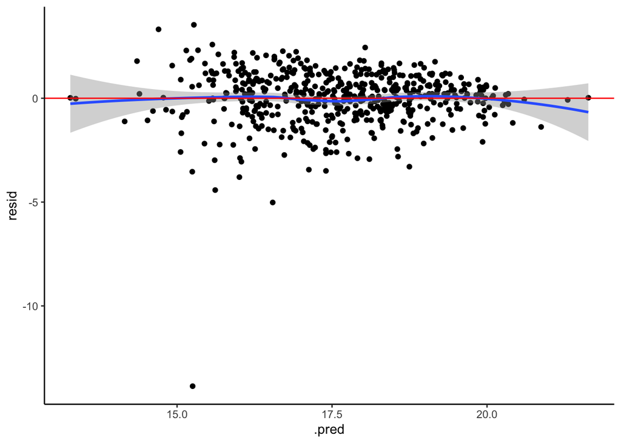

```r
# Visualize Residuals
lasso_mod_out1 <- new_mod %>%
    predict(new_data = imdb_clean) %>%
    bind_cols(imdb_clean) %>%
    mutate(resid = Gross - .pred)


ggplot(lasso_mod_out1, aes(x = .pred, y = resid)) +
    geom_point() +
    geom_smooth() +
    geom_hline(yintercept = 0, color = "red") +
    theme_classic()
```

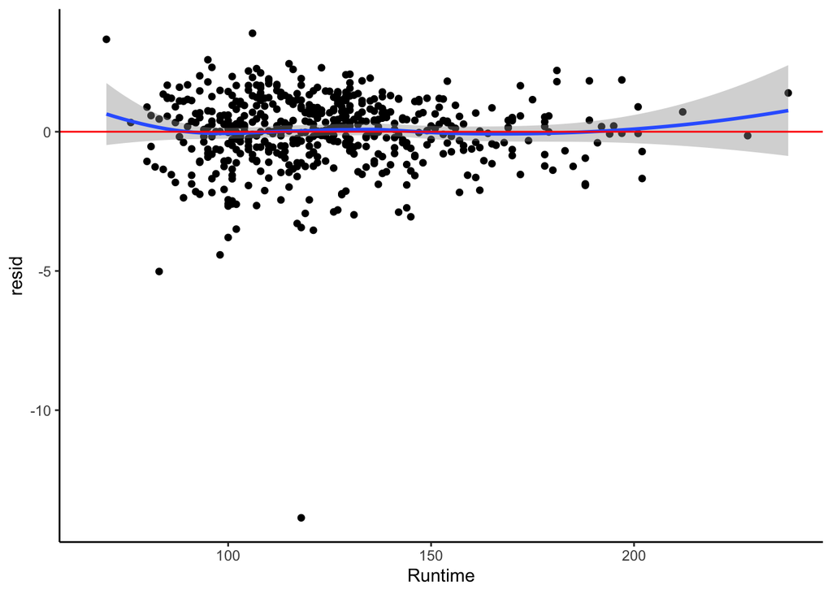

```r
ggplot(lasso_mod_out1, aes(x = Runtime, y = resid)) +
    geom_point() +
    geom_smooth() +
    geom_hline(yintercept = 0, color = "red") +
    theme_classic()
```

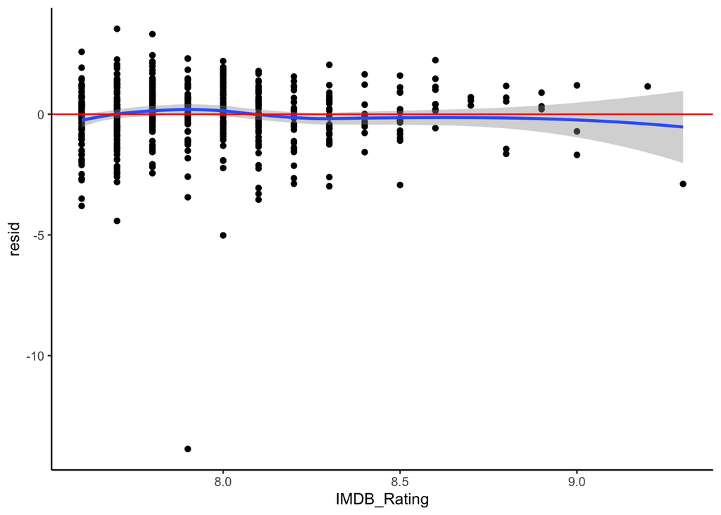

```r
ggplot(lasso_mod_out1, aes(x = IMDB_Rating, y = resid)) +
    geom_point() +
    geom_smooth() +
    geom_hline(yintercept = 0, color = "red") +
    theme_classic()
```

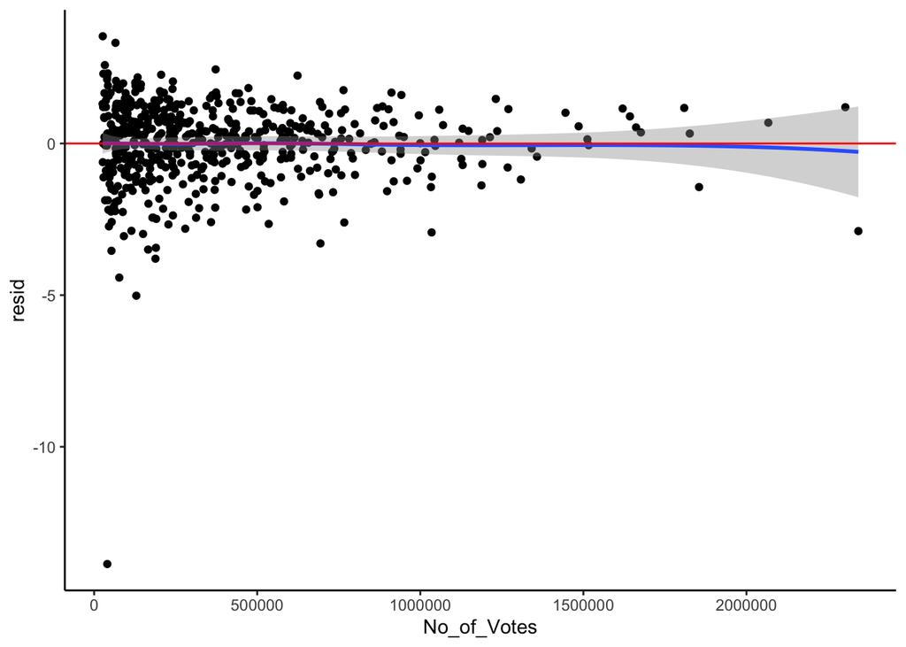

```r
ggplot(lasso_mod_out1, aes(x = No_of_Votes, y = resid)) +
    geom_point() +
    geom_smooth() +
    geom_hline(yintercept = 0, color = "red") +
    theme_classic()
```

# Comparing Model Performance

```r
full_modelcv %>% collect_metrics() #OLS
```

| .metric | .estimator | mean | n | std_err | .config |
| --- | --- | --- | --- | --- | --- |
| mae | standard | 1.0346438 | 10 | 0.04089512 | Preprocessor1_Model1 |
| rmse | standard | 1.4101244 | 10 | 0.11113687 | Preprocessor1_Model1 |
| rsq | standard | 0.4554289 | 10 | 0.03354154 | Preprocessor1_Model1 |

```r
lasso_fit %>% collect_metrics() #LASSO
```

| .metric | .estimator | mean | n | std_err | .config |
| --- | --- | --- | --- | --- | --- |
| mae | standard | 1.0701786 | 10 | 0.04736947 | Preprocessor1_Model1 |
| rmse | standard | 1.4605430 | 10 | 0.12348626 | Preprocessor1_Model1 |
| rsq | standard | 0.4724709 | 10 | 0.02825634 | Preprocessor1_Model1 |

```r
new_modcv %>% collect_metrics() #GAM
```

| .metric | .estimator | mean | n | std_err | .config |
| --- | --- | --- | --- | --- | --- |
| mae | standard | 0.9934404 | 10 | 0.04608704 | Preprocessor1_Model1 |
| rmse | standard | 1.3517138 | 10 | 0.10771984 | Preprocessor1_Model1 |
| rsq | standard | 0.5035762 | 10 | 0.02729763 | Preprocessor1_Model1 |

# Summarize Investigations

The goal of our investigations is to accurately predict a movie’s gross box office gross revenue based on a number of predictors. We compared three different model types: ordinary linear regression (OLS) with all predictors, OLS using LASSO to select a subset of variables, and a GAM using splines to account for nonlinearity. The GAM model has the lowest RMSE but could be difficult to interpret. We are looking forward to continuing our investigations using Decision Trees which may offer a more easily interpreted method for modeling nonlinearity. Ideally, we would like an accurate model that is relatively easy to interpret.

# Societal Impact

In addition to our earlier discussion of societal impacts that our model may have, we want to keep in mind the biases of the Hollywood movie industry. Representation of different races, genders, abilities, etc. is an issue in Hollywood/the greater film industry, and it is likely that the harm our model/analysis produces is already in line with the issues that created and maintain this. This is because the data we have is from past movies that came out of this system. This means that whatever made a movie successful, whether it’s due to certain actors, directors, etc., is a standard that already existed. If we see the movies that have done really well have predominantly white casts, then it is likely a result of a longstanding issue of racism in the movie industry. Our model can’t account for that, but we are aware of it.

```r
imdb_clean_class <- imdb_clean %>%
  mutate(success_ratio = Revenue/Budget) %>%
  mutate(flop = as.factor(ifelse(success_ratio > 1.5, 'FALSE', 'TRUE'))) %>%
  filter(!is.na(flop)) %>%
  filter(Gross != "NaN") %>%
  filter(success_ratio != "Inf") %>%
  filter(Budget > 10)
```

# Bagging and Random Forests

```r
# Model Specification
rf_spec <- rand_forest() %>%
  set_engine(engine = 'ranger') %>%
  set_args(mtry = 4, # size of random subset of variables; default is floor(sqrt(number of total predictors))
           trees = 1000, # Number of trees
           min_n = NULL,
           probability = FALSE, # FALSE: get hard predictions (not needed for regression)
           importance = 'impurity') %>% # we'll come back to this at the end
  set_mode('classification') # change this for regression

# Recipe
data_rec <- recipe(flop ~ No_of_Votes + Runtime + IMDB_Rating + Meta_score + Genre_1,
                   data = imdb_clean_class) %>%
  step_naomit(flop, No_of_Votes, Runtime, IMDB_Rating, Meta_score, Genre_1)

# Workflows
data_wf_mtry150 <- workflow() %>%
  add_model(rf_spec %>% set_args(mtry = 150)) %>%
  add_recipe(data_rec)

## Create workflows for min_n = 10, 25, and 50

data_wf_mtry125 <- workflow() %>%
  add_model(rf_spec %>% set_args(mtry = 125)) %>%
  add_recipe(data_rec)

data_wf_mtry75 <- workflow() %>%
  add_model(rf_spec %>% set_args(mtry = 75)) %>%
  add_recipe(data_rec)

data_wf_mtry100 <- workflow() %>%
  add_model(rf_spec %>% set_args(mtry = 100)) %>%
  add_recipe(data_rec)
```

```r
# Fit Models
set.seed(123) # make sure to run this before each fit so that you have the same 1000 trees
data_fit_mtry150 <- fit(data_wf_mtry150, data = imdb_clean_class)

# Fit models for 10, 25, and 50
set.seed(123)
data_fit_mtry125 <- fit(data_wf_mtry125, data = imdb_clean_class)

set.seed(123)
data_fit_mtry75 <- fit(data_wf_mtry75, data = imdb_clean_class)

set.seed(123)
data_fit_mtry100 <- fit(data_wf_mtry100, data = imdb_clean_class)
```

```r
# Custom Function to get OOB predictions, true observed outcomes and add a user-provided model label
rf_OOB_output <- function(fit_model, model_label, truth){
    tibble(
          .pred_class = fit_model %>% extract_fit_engine() %>% pluck('predictions'), #OOB predictions
          flop = truth,
          label = model_label
      )
}

rf_OOB_output(data_fit_mtry150,150, imdb_clean_class %>% pull(flop))
```

[output not shown]

```r
# Evaluate OOB Metrics

data_rf_OOB_output <- bind_rows(
    rf_OOB_output(data_fit_mtry150,150, imdb_clean_class %>% pull(flop)),
    rf_OOB_output(data_fit_mtry125,125, imdb_clean_class %>% pull(flop)),
    rf_OOB_output(data_fit_mtry75,75, imdb_clean_class %>% pull(flop)),
    rf_OOB_output(data_fit_mtry100,100, imdb_clean_class %>% pull(flop))
)
```

[output not shown]

```r
data_rf_OOB_output %>%
    group_by(label) %>%
    accuracy(truth = flop, estimate = .pred_class)
```

[output not shown]

### Evaluating the Forest

```r
rf_OOB_output(data_fit_mtry125,125, imdb_clean_class %>% pull(flop)) %>%
    conf_mat(truth = class, estimate= .pred_class)
```

[output not shown]

### Variable Importance

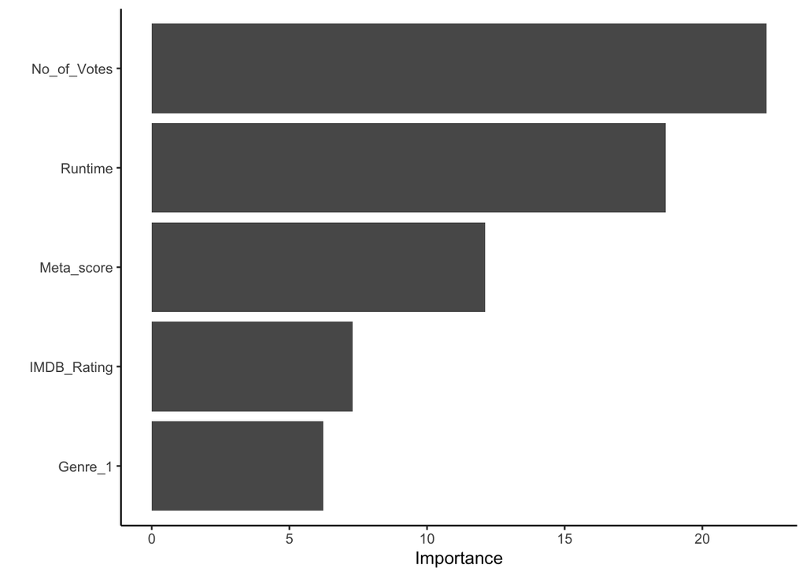

```r
# Impurity

model_output <-data_fit_mtry125 %>%
    extract_fit_engine()

model_output %>%
    vip(num_features = 10) + theme_classic() #based on impurity, 10 meaning the top 10
```

```r
model_output %>% vip::vi() %>% head()
```

| Variable | Importance |
| --- | --- |
| No_of_Votes | 22.331104 |
| Runtime | 18.660300 |
| Meta_score | 12.119085 |
| IMDB_Rating | 7.301732 |
| Genre_1 | 6.234952 |

```r
model_output %>% vip::vi() %>% tail()
```

| Variable | Importance |
| --- | --- |
| No_of_Votes | 22.331104 |
| Runtime | 18.660300 |
| Meta_score | 12.119085 |
| IMDB_Rating | 7.301732 |
| Genre_1 | 6.234952 |

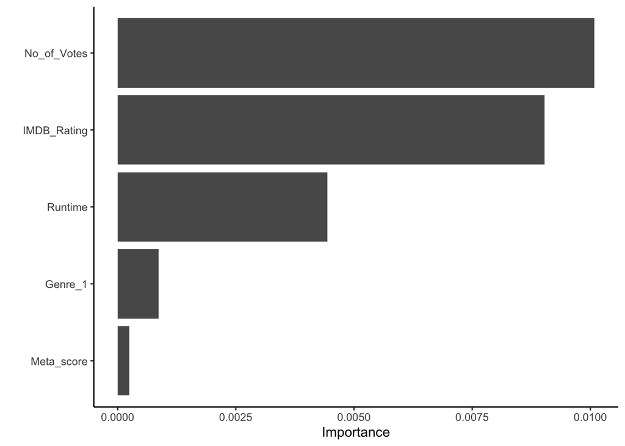

```r
# Permutation

model_output2 <- data_wf_mtry125 %>%
  update_model(rf_spec %>% set_args(importance = "permutation")) %>% #based on permutation
  fit(data = imdb_clean_class) %>%
    extract_fit_engine()

model_output2 %>%
    vip(num_features = 10) + theme_classic()
```

```r
model_output2 %>% vip::vi() %>% head()
```

| Variable | Importance |
| --- | --- |
| No_of_Votes | 0.0100855540 |
| IMDB_Rating | 0.0090288808 |
| Runtime | 0.0044355680 |
| Genre_1 | 0.0008653966 |
| Meta_score | 0.0002487035 |

```r
model_output2 %>% vip::vi() %>% tail()
```

| Variable | Importance |
| --- | --- |
| No_of_Votes | 0.0100855540 |
| IMDB_Rating | 0.0090288808 |
| Runtime | 0.0044355680 |
| Genre_1 | 0.0008653966 |
| Meta_score | 0.0002487035 |

# Logistic Regression

```r
set.seed(123)

# Logistic Regression Model Spec
logistic_spec <- logistic_reg() %>%
    set_engine('glm') %>%
    set_mode('classification')
# Recipe
logistic_rec <- recipe(flop ~ IMDB_Rating, No_of_Votes, gross,
                   data = imdb_clean_class)
# Workflow (Recipe + Model)
log_wf <- workflow() %>%
    add_recipe(logistic_rec) %>%
    add_model(logistic_spec)
# Fit Model
log_fit <- fit(log_wf, data = imdb_clean_class)

tidy(log_fit)
```

| term | estimate | std.error | statistic | p.value |
| --- | --- | --- | --- | --- |
| (Intercept) | 2.5226803 | 4.9895230 | 0.5055955 | 0.6131407 |
| IMDB_Rating | -0.6462767 | 0.6300713 | -1.0257200 | 0.3050236 |

```r
log_fit %>% tidy() %>%
  mutate(OR = exp(estimate))
```

| term | estimate | std.error | statistic | p.value | OR |
| --- | --- | --- | --- | --- | --- |
| (Intercept) | 2.5226803 | 4.9895230 | 0.5055955 | 0.6131407 | 12.4619536 |
| IMDB_Rating | -0.6462767 | 0.6300713 | -1.0257200 | 0.3050236 | 0.5239931 |

```r
predict(log_fit, new_data = data.frame(IMDB_Rating = 5, No_of_Votes = 500000, gross = 18), type = "prob"
)
```

| .pred_FALSE | .pred_TRUE |
| --- | --- |
| 0.6701146 | 0.3298854 |

```r
predict(log_fit, new_data = data.frame(IMDB_Rating = 5, No_of_Votes = 500000, gross = 18), type = "class"
)
```

| .pred_class |
| --- |
| FALSE |